# Single-Cell Omics Research and Education

SCORE #4: CellChat

Jonathan Nelson and Kevin Burfeind

28 April 2025

```r
library("dplyr")
library("Seurat")
library("knitr")
library("ggplot2")
library("BiocManager")
library("here")
#BiocManager::install("EnhancedVolcano")
library("EnhancedVolcano") #volcano plot
#install.packages('DESeq2') #for DEG
library("DESeq2")
library("tidyverse") #tidy up data
library("styler") #tidy up data


if (!require("kableExtra")) {install.packages("kableExtra"); require("kableExtra")} # for color brewer
if (!require("RColorBrewer")) {install.packages("RColorBrewer"); require("RColorBrewer")} # for color brewer
if (!require("sctransform")) {install.packages("sctransform"); require("sctransform")} # for data normalization
if (!require("glmGamPoi")) {BiocManager::install('glmGamPoi'); require("glmGamPoi")} # for data normalization, sctransform
if (!require("cowplot")) {install.packages("cowplot"); require("cowplot")} # for figure layout
if (!require("patchwork")) {install.packages("patchwork"); require("patchwork")} # for figure patching
if (!require("openxlsx")) {install.packages("openxlsx"); require("openxlsx")} # to save .xlsx files

# install.packages("styler")



set.seed(12345)
# here()
```

# 1 Welcome

Welcome to the **Single-Cell Omics Research and Education Club**!

If this is your time to the club, **I want to extend and extra-special welcome to you!**

I’m **Jonathan Nelson**, an Assistant Professor at the University of Southern California. I’m a **wet** scientist turned **wet+dry** scientist. I’ve been working with **single-cell RNAseq data** for the past **5 years** and I’m excited to share what I’ve learned with you.

## 1.1 SCORE Values

### 1.1.1 **Learning**

We believe that bioinformatics is a constantly evolving field, and that ongoing learning and professional development is essential to staying up-to-date. We encourage members to share their knowledge and experiences with each other, and to seek out opportunities for continued learning.

### 1.1.2 **Accessibility**

We believe that access to bioinformatics support should be available to everyone. We strive to create a welcoming and inclusive environment where all members can feel comfortable asking for help and contributing to the group.

### 1.1.3 **Collaboration**

We believe that working together is key to achieving success in bioinformatics. We value the diversity of perspectives and backgrounds that each member brings, and we encourage open communication and the sharing of ideas.

### 1.1.4 **Integrity**

We believe in conducting ourselves with honesty and professionalism in all our interactions. We hold ourselves to high ethical standards and respect the privacy and confidentiality of all members.

### 1.1.5 **Empathy**

We believe in approaching each other with empathy and kindness. We understand that bioinformatics can be a challenging and sometimes frustrating field, and we strive to support each other through these difficulties.

## 1.2 Context and Expectations

I know a lot of this has been going on in the background for everyeone and I wanted to bring it to the forefront. **My expectation** is that we have **about 6 of these meetings** together and then we can re-evaluate if we want to continue as a group or not.

Email me you would like me to add anyone: **j.nelson@med.usc.edu**

Today’s code (**this html file**) will be posted to the SCORE website (https://usckrc.github.io/website/score.html)

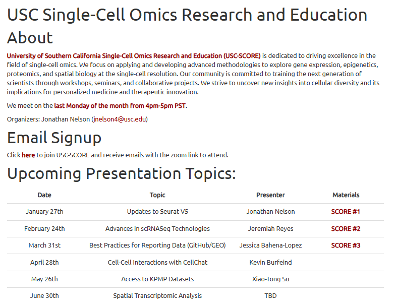

# 2 The Agenda!

## 2.1 Music and Memes

## 2.2 Coding Crumbs: **Gene Conversion**

## 2.3 Recreating a Figure: **Sankey Plot**

## 2.4 Main Theme: **CellChat**

# 3 Music and Memes

## 3.1 This Months Coding Music

**The Antlers**: Green to Gold

https://open.spotify.com/album/72XWeRa3UZSkxLkGs2kTHo?si=w8GI4_W4QlyeBYmtA6kiUg

[figure not shown]

## 3.2 The Memes!

[figure not shown]

[figure not shown]

[figure not shown]

[figure not shown]

# 4 Coding Crumbs: **Gene Conversion**

[figure not shown]

## 4.1 Changing between **Mouse** and **Human** gene names is common maneuver

## 4.2 Why?

### 4.2.1 Translational Research

### 4.2.2 Target Identification for Therapies

### 4.2.3 Pathway and Functional Annotation

## 4.3 It’s a Challenge

### 4.3.1 Gene Duplications

### 4.3.2 Unique Names

## 4.4 Approaches I’ve used before

### 4.4.1 **Packages**

#### 4.4.1.1 **geneName**

https://github.com/mustafapir/geneName

##### 4.4.1.1.1 Install

```r
if (!require("geneName")) {install.packages("geneName"); require("geneName")}
```

#### 4.4.1.2 Usage

```r
df_human <- mousegnameConverter(df_mouse, "gene")
```

### 4.4.2 **ChatGPT**

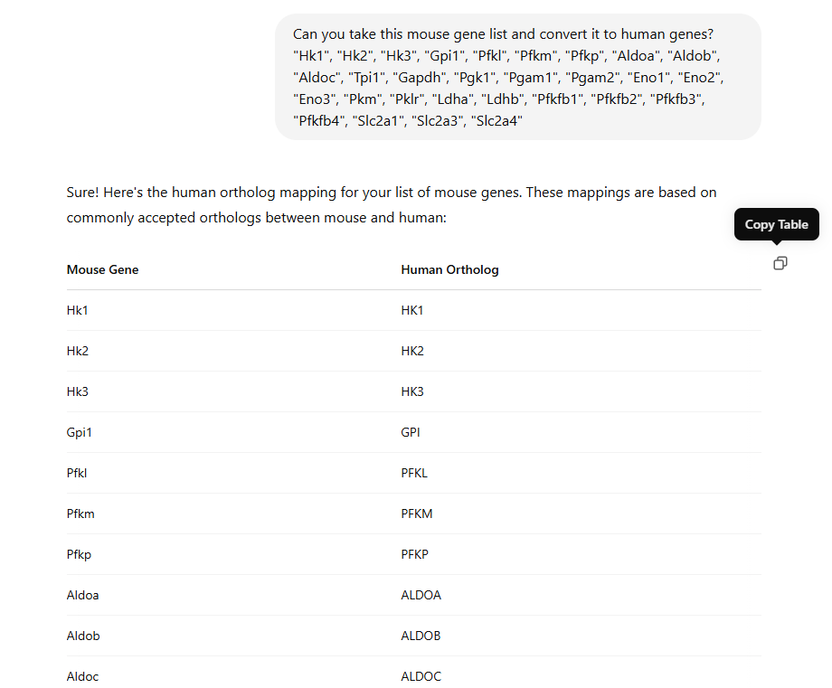

#### 4.4.2.1 Use at your own risk.

##### 4.4.2.1.1 Quick…but unreliable

### 4.4.3 **Functions**

https://www.biostars.org/p/9567892/

#### 4.4.3.1 Human -> Mouse

```r
convert_human_to_mouse <- function(gene_list) {
    output = c()
    mouse_human_genes = read.csv("https://www.informatics.jax.org/downloads/reports/HOM_MouseHumanSequence.rpt",sep="\t")

    for(gene in gene_list) {
          class_key = (mouse_human_genes %>% filter(Symbol == gene & Common.Organism.Name == "human"))[['DB.Class.Key']]
          if( !identical(class_key, integer(0)) ) {
            human_genes = (mouse_human_genes %>% filter(DB.Class.Key == class_key & Common.Organism.Name=="mouse, laboratory"))[,"Symbol"]
            for(human_gene in human_genes) {
                output = rbind(c(gene, human_gene), output)
            }
          }
     }
     return (output)
}

df_mouse_gene <- convert_human_to_mouse(gene_list)

df_mouse_gene <- as.data.frame(df_mouse_gene)
```

#### 4.4.3.2 Mouse -> Human

```r
convert_mouse_to_human <- function(gene_list) {
     output = c()
     mouse_human_genes = read.csv("https://www.informatics.jax.org/downloads/reports/HOM_MouseHumanSequence.rpt",sep="\t")

     for(gene in gene_list) {
          class_key = (mouse_human_genes %>% filter(Symbol == gene & Common.Organism.Name == "mouse, laboratory"))[['DB.Class.Key']]
          if( !identical(class_key, integer(0)) ) {
               human_genes = (mouse_human_genes %>% filter(DB.Class.Key == class_key & Common.Organism.Name=="human"))[,"Symbol"]
               for(human_gene in human_genes) {
                    output = rbind(c(gene, human_gene), output)
               }
          }
     }
     return (output)
}

df_human_gene <- convert_mouse_to_human(gene_list)

df_human_gene <- as.data.frame(df_human_gene)
```

## 4.5 **Take Home**

### 4.5.1 **Function** is what I use now.

#### 4.5.1.1 I should probably **download the database** localy onto my computer

### 4.5.2 I suspect there are **other options**.

#### 4.5.2.1 BioMart?

#### 4.5.2.2 How do others in the **chat** do this?

# 5 Recreating a Figure: **Sankey Plot**

[figure not shown]

## 5.1 Final Product!

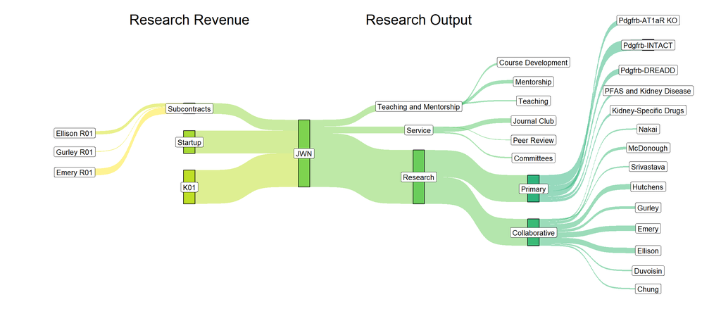

## 5.2 Inspiration

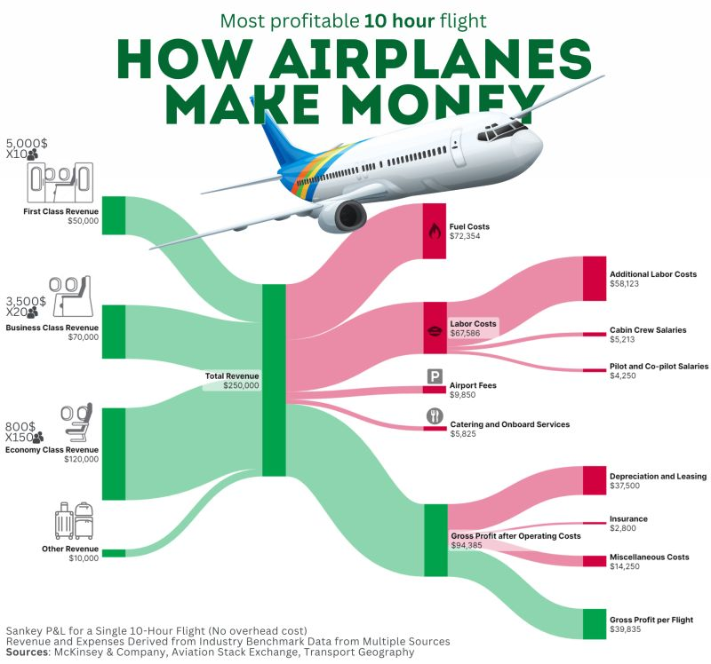

[**Source**](https://www.linkedin.com/posts/lirimzenuni-bi-king_sankey-pl-for-the-most-profitable-10-hour-activity-7213840792409272320-nwO1)

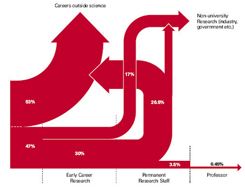

[**Source**](https://academia.stackexchange.com/questions/17431/what-ratio-of-phd-graduates-in-stem-fields-ultimately-end-up-as-tenured-profes)

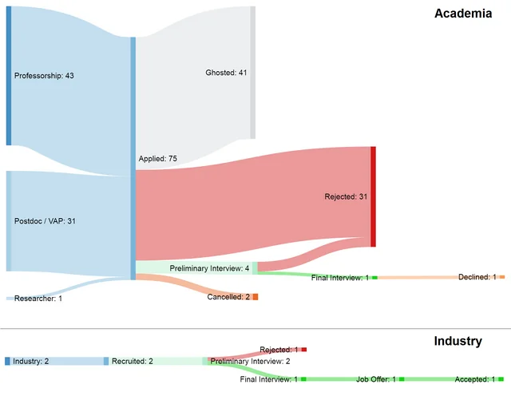

[**Source**](https://www.reddit.com/r/math/comments/ccd9sl/my_job_hunt_as_a_new_phd/)

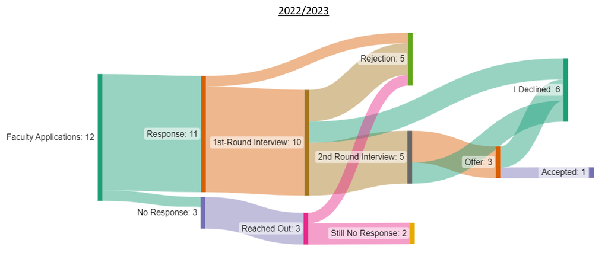

[**Source**](https://www.reddit.com/r/academia/comments/16lyfx3/3_year_faculty_application_journey_in_sankey/)

## 5.3 History

[figure not shown]

[figure not shown]

[**Sankey Wiki**](https://en.wikipedia.org/wiki/Sankey_diagram)

## 5.4 **Lessons** for Me

### 5.4.1 **Layering** a graph with different dataframes

### 5.4.2 **Leveling** a graph with data

### 5.4.3 **Setting** a color palette

## 5.5 Starting Place

I wanted to **start with easy .xlsx file** that was flexible to fill out.

### 5.5.1 Research Input

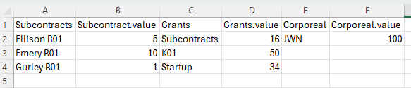

### 5.5.2 Research Output

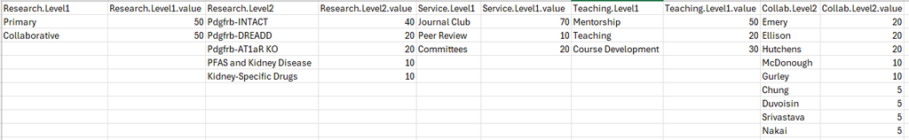

```r
if (!require("here")) {install.packages("here"); require("here")}
if (!require("openxlsx")) {install.packages("openxlsx"); require("openxlsx")}
if (!require("plotly")) {install.packages("plotly"); require("plotly")}
library(tidyr)

#remotes::install_github("davidsjoberg/ggsankey")
library(ggsankey)

df <- read.xlsx(here("Week 4 CellChat", "data", "Revenue Input.xlsx"))
```

### 5.5.3 Create a dataframe with proportional entries

```r
df_subcontract <- df %>%
  uncount(Subcontract.value, .remove = FALSE) %>%
  mutate(Subcontract_Number = Subcontracts) %>%
  select(Subcontracts)


df_Grants <- df %>%
  uncount(Grants.value, .remove = FALSE) %>%
  mutate(Grants.Number = Grants) %>%
  select(Grants)

df1 <- df_subcontract
df2 <- df_Grants

max_rows <- max(nrow(df1), nrow(df2))

df1_extended <- df1 %>%
  bind_rows(tibble(Subcontracts = rep(NA, max_rows - nrow(df1))))

df2_extended <- df2 %>%
  bind_rows(tibble(Grants = rep(NA_character_, max_rows - nrow(df2))))

df_merged <- cbind(df1_extended , df2_extended)

df_merged$Corporeal <- "JWN"
```

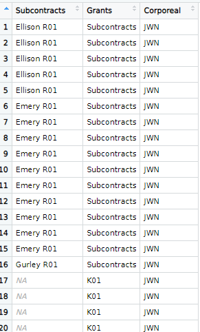

### 5.5.4 Convert into a **Sankey** format

```r
df3 <- df_merged %>% make_long(Subcontracts, Grants, Corporeal) %>%
  filter(!is.na(node))
```

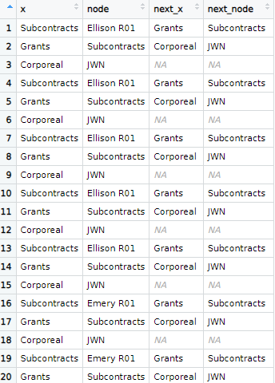

## 5.6 **Create** Sankey plot

**ggplot2 object** > **sankey layering** > **theme** > **plot**

Interestingly, the ggplot2 object is **blank** if you try to plot it.

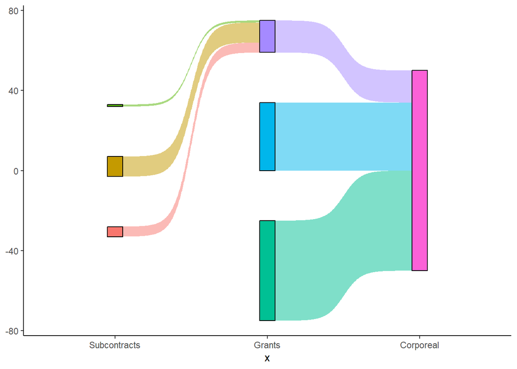

```r
df3.input <- df3

p1 <- ggplot(df3, aes(x = x
                     , next_x = next_x
                     , node = node
                     , next_node = next_node
                     , fill = factor(node)
                     , label = node)
             )

p1 <- p1 +geom_sankey(flow.alpha = 0.5
                      , node.color = "black"
                      ,show.legend = FALSE)

p1 <- p1 + theme_classic() + theme(legend.position = "none")


p1
```

### 5.6.1 I found interactive **plotly** format helpful for troubleshooting

Because categories are not labeled in chart.

```r
p_plotly <- ggplotly(p1, tooltip = "text")

p_plotly
```

[interactive chart not shown]

## 5.7 Add **Research Output**: Level 0

```r
df <- read.xlsx(here("Week 4 CellChat", "data", "Research Output.xlsx"))

df[is.na(df)] <- 0

df_Main <- df %>%
  uncount(Main.value, .remove = FALSE) %>%
  mutate(Main_Number = Main) %>%
  select(Main)

df3 <- df_Main
df3$Corporeal <- "JWN"

# Make Corporeal the first column using dplyr

df3 <- df3 %>% select(Corporeal, Main)

df3 <- df3 %>% make_long(Corporeal, Main) %>%
  filter(!is.na(node))

df4 <- rbind(df3.input, df3)

df4 <- df4 %>% filter(!(x == "Corporeal" & is.na(next_x)))

p1 <- ggplot(df4, aes(x = x
                     , next_x = next_x
                     , node = node
                     , next_node = next_node
                     , fill = factor(node)
                     , label = node)
             )

p1 <- p1 +geom_sankey(flow.alpha = 0.5
                      , node.color = "black"
                      ,show.legend = FALSE)


p_plotly <- ggplotly(p1, tooltip = "text")

p_plotly
```

[interactive chart not shown]

## 5.8 Add **Level 1**

### 5.8.1 Research Details

```r
research_value <- df %>%
  filter(Main == "Research") %>%
  pull(Main.value) %>%
  `/`(100)

df_Research.Level1 <- df %>%
    uncount(Research.Level1.value * research_value, .remove = FALSE) %>%
  mutate(Level1 = Research.Level1) %>%
  select(Level1)

df3 <- df_Research.Level1
df3$Main <- "Research"

df3 <- df3 %>% select(Main, Level1)

df3 <- df3 %>% make_long(Main, Level1) %>%
  filter(!is.na(node))

df4 <- rbind(df4, df3)

df5 <- df4 %>% filter(!(x == "Main" & node == "Research" & is.na(next_x)))

p1 <- ggplot(df5, aes(x = x
                     , next_x = next_x
                     , node = node
                     , next_node = next_node
                     , fill = factor(node)
                     , label = node)
             )

p1 <- p1 +geom_sankey(flow.alpha = 0.5
                      , node.color = "black"
                      ,show.legend = FALSE)

p_plotly <- ggplotly(p1, tooltip = "text")

p_plotly
```

[interactive chart not shown]

### 5.8.2 Service Details

```r
service_value <- df %>%
  filter(Main == "Service") %>%
  pull(Main.value) %>%
  `/`(100)

df[is.na(df)] <- 0

df_Service.Level1 <- df %>%
  uncount(Service.Level1.value * service_value, .remove = FALSE) %>%
  mutate(Level1 = Service.Level1) %>%
  select(Level1)

df3 <- df_Service.Level1
df3$Main <- "Service"

df3 <- df3 %>% select(Main, Level1)

df3 <- df3 %>% make_long(Main, Level1) %>%
  filter(!is.na(node))

df5 <- rbind(df5, df3)

df6 <- df5 %>% filter(!(x == "Main" & node == "Service" & is.na(next_x)))

p1 <- ggplot(df6, aes(x = x
                     , next_x = next_x
                     , node = node
                     , next_node = next_node
                     , fill = factor(node)
                     , label = node)
             )

p1 <- p1 +geom_sankey(flow.alpha = 0.5
                      , node.color = "black"
                      ,show.legend = FALSE
                      ,type = "sankey")

p_plotly <- ggplotly(p1, tooltip = "text")

p_plotly
```

[interactive chart not shown]

### 5.8.3 Teaching Details

```r
Teaching_value <- df %>%
  filter(Main == "Teaching and Mentorship") %>%
  pull(Main.value) %>%
  `/`(100)

df[is.na(df)] <- 0

df_Teaching.Level1 <- df %>%
  uncount(Teaching.Level1.value * Teaching_value, .remove = FALSE) %>%
  mutate(Level1 = Teaching.Level1) %>%
  select(Level1)

df3 <- df_Teaching.Level1
df3$Main <- "Teaching and Mentorship"

df3 <- df3 %>% select(Main, Level1)

df3 <- df3 %>% make_long(Main, Level1) %>%
  filter(!is.na(node))

df6 <- rbind(df6, df3)

df7 <- df6 %>% filter(!(x == "Main" & node == "Teaching and Mentorship" & is.na(next_x)))

p1 <- ggplot(df6, aes(x = x
                     , next_x = next_x
                     , node = node
                     , next_node = next_node
                     , fill = factor(node)
                     , label = node)
             )

p1 <- p1 +geom_sankey(flow.alpha = 0.5
                      , node.color = "black"
                      ,show.legend = FALSE
                      ,type = "sankey")

p_plotly <- ggplotly(p1, tooltip = "text")

p_plotly
```

[interactive chart not shown]

## 5.9 Add **Level 2**

### 5.9.1 Collab

```r
Collab_value <- df %>%
  filter(Research.Level1 == "Collaborative") %>%
  pull(Research.Level1.value) %>%
  `/`(100)

df[is.na(df)] <- 0

df_Collab.Level2 <- df %>%
  uncount(Collab.Level2.value * Collab_value * research_value, .remove = FALSE) %>%
  mutate(Level2 = Collab.Level2) %>%
  select(Level2)

df3 <- df_Collab.Level2
df3$Level1 <- "Collaborative"

df3 <- df3 %>% select(Level1, Level2)

df3 <- df3 %>% make_long(Level1, Level2) %>%
  filter(!is.na(node))

df8 <- rbind(df7, df3)

df9 <- df8 %>% filter(!(x == "Level1" & node == "Collaborative" & is.na(next_x)))

p1 <- ggplot(df9, aes(x = x
                     , next_x = next_x
                     , node = node
                     , next_node = next_node
                     , fill = factor(node)
                     , label = node)
             )

p1 <- p1 +geom_sankey(flow.alpha = 0.5
                      , node.color = "black"
                      ,show.legend = FALSE
                      ,type = "sankey")

p_plotly <- ggplotly(p1, tooltip = "text")

p_plotly
```

[interactive chart not shown]

### 5.9.2 Primary Research

```r
df9 <- df8 %>% filter(!(x == "Level1" & node == "Collaborative" & is.na(next_x)))

Primary_value <- df %>%
  filter(Research.Level1 == "Primary") %>%
  pull(Research.Level1.value) %>%
  `/`(100)

df[is.na(df)] <- 0

df_Research.Level2 <- df %>%
  uncount(Research.Level2.value * Primary_value * research_value, .remove = FALSE) %>%
  mutate(Level2 = Research.Level2) %>%
  select(Level2)

df3 <- df_Research.Level2
df3$Level1 <- "Primary"

df3 <- df3 %>% select(Level1, Level2)

df3 <- df3 %>% make_long(Level1, Level2) %>%
  filter(!is.na(node))

df10 <- rbind(df9, df3)

df11 <- df10 %>% filter(!(x == "Level1" & node == "Primary" & is.na(next_x)))

p1 <- ggplot(df11, aes(x = x
                     , next_x = next_x
                     , node = node
                     , next_node = next_node
                     , fill = factor(node)
                     , label = node)
             )

p1 <- p1 +geom_sankey(flow.alpha = 0.5
                      , node.color = "black"
                      ,show.legend = FALSE
                      ,type = "sankey")

p_plotly <- ggplotly(p1, tooltip = "text")

p_plotly
```

[interactive chart not shown]

## 5.10 Aesthetics

### 5.10.1 Factor nodes in correct order

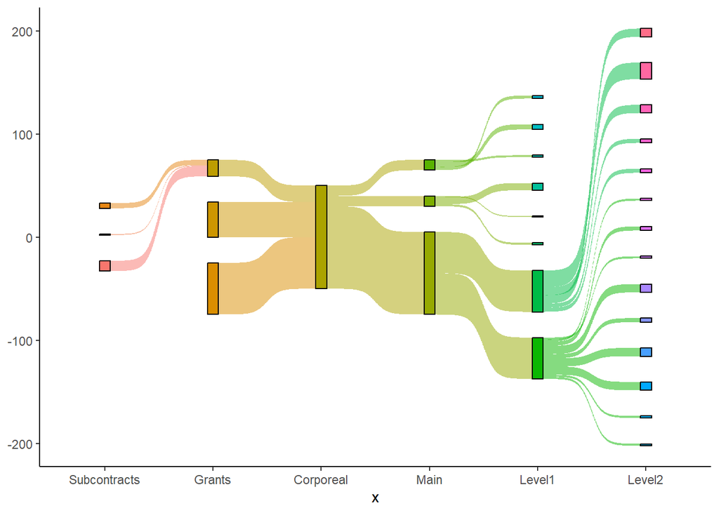

```r
df.test <- df11

df.test$node <- as.factor(df.test$node)

# levels(df.test$node)

levels_to_assign <- c("Emery R01",
                      "Gurley R01",
                      "Ellison R01",

                      "K01",
                      "Startup",
                      "Subcontracts",

                       "JWN",

                      "Research",
                      "Service",
                      "Teaching and Mentorship",

                      "Collaborative",
                      "Primary",

                      "Committees",
                      "Peer Review",
                      "Journal Club",
                      "Teaching",
                      "Mentorship",
                      "Course Development",


                      "Chung",
                      "Duvoisin",

                      "Ellison",
                      "Emery",
                      "Gurley",
                      "Hutchens",
                      "Srivastava",
                      "McDonough",
                      "Nakai",

                      "Kidney-Specific Drugs",
                      "PFAS and Kidney Disease",
                      "Pdgfrb-DREADD",
                      "Pdgfrb-INTACT",
                      "Pdgfrb-AT1aR KO"

                      )


df.test$node <- factor(df.test$node, levels = levels_to_assign)


p1 <- ggplot(df.test, aes(x = x
                     , next_x = next_x
                     , node = node
                     , next_node = next_node
                     , fill = factor(node)
                     , label = node)
             )

p1 <- p1 +geom_sankey(flow.alpha = 0.5
                      , node.color = "black"
                      ,show.legend = FALSE)


p1 <- p1 + theme_classic() + theme(legend.position = "none")

p1
```

```r
p_plotly <- ggplotly(p1, tooltip = "text")

p_plotly
```

[interactive chart not shown]

### 5.10.2 ggplot2 tests

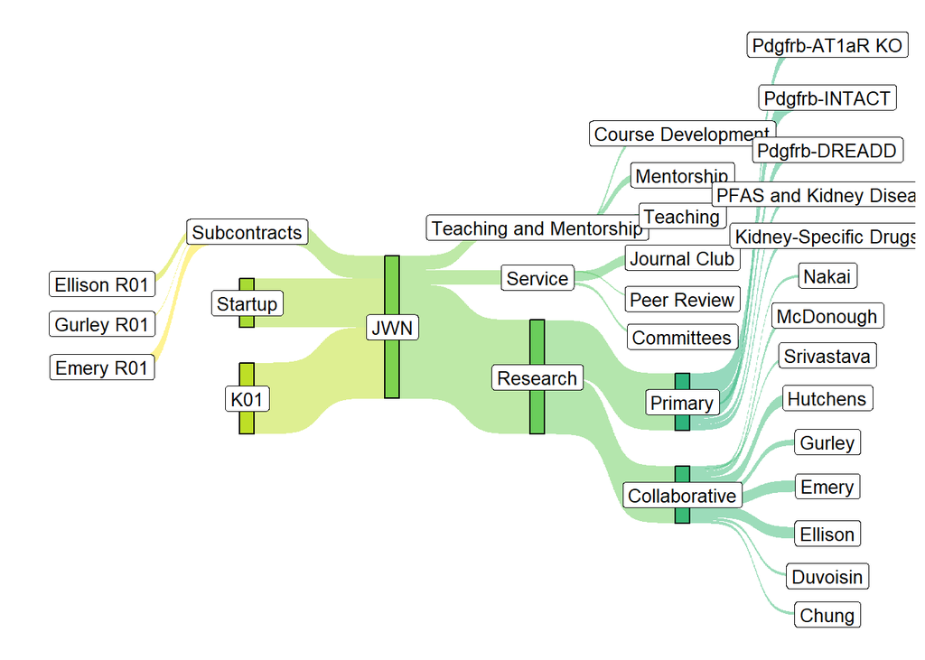

```r
p1 <- p1 + theme_classic() + theme(legend.position = "none") +
  geom_sankey_label(size = 3.5, color = 1, fill = "white")

# remove axis lines and axis labels

p1 <- p1 + theme(axis.line = element_blank(),
                 axis.text.x = element_blank(),
                 axis.text.y = element_blank(),
                 axis.ticks = element_blank(),
                 axis.title.x = element_blank(),
                 axis.title.y = element_blank())


p2 <- p1 + scale_fill_viridis_d(direction = -1, option = "viridis") +
      scale_colour_viridis_d(direction = -1, option = "viridis")
p2
```

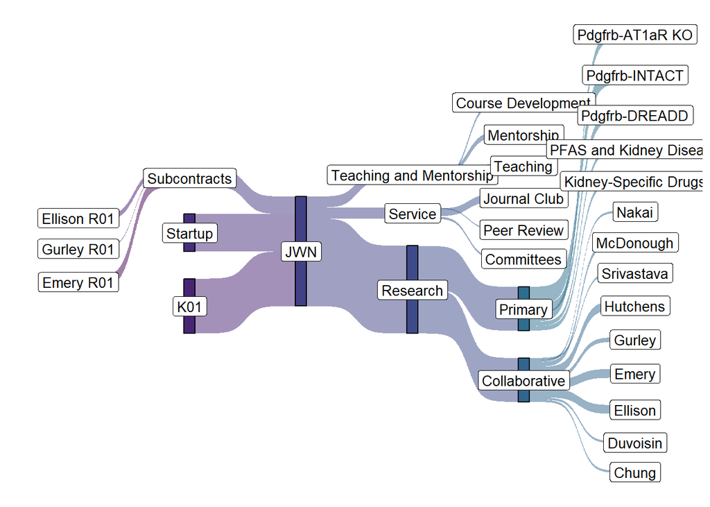

```r
p3 <- p1 + scale_fill_viridis_d(direction = 1, option = "viridis") +
      scale_colour_viridis_d(direction = 1, option = "viridis")
p3
```

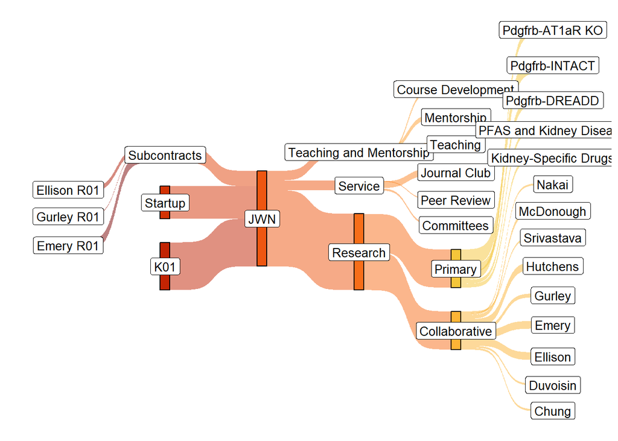

```r
p4 <- p1 + scale_fill_viridis_d(direction = -1, option = "turbo") +
      scale_colour_viridis_d(direction = -1, option = "turbo")
p4
```